# Exploratory Data Analysis of Used Cars

#Intro: In this notebook, we will perform an exploratory data analysis (EDA) on a used car dataset. The primary goals are to clean and preprocess the data, understand the dataset’s structure, and visualize critical relationships among variables. To uncover insights into the used car market, we will analyze various attributes, including price, mileage, and model year. Additionally, we will create visualizations to highlight trends and patterns, such as the relationship between mileage and cost, and identify the most popular and expensive car brands. This analysis aims to provide a comprehensive overview of the factors affecting used car pricing and performance.

# Load libraries

```r
install.packages("tidyverse")
install.packages("knitr")
install.packages("scales")
install.packages("ggplot2")
install.packages("corrplot")
install.packages("reshape2")

library(corrplot)
library(ggplot2)
library(tidyverse)
library(knitr)
library(readr)
library(scales)
library(dplyr)
library(lubridate)
library(reshape2)
```

# Import dataset

```r
used_cars_dataset <- read_csv("~/Desktop/Data sets/used_cars.csv")
```

# Cleaning

```r
# Rename the column
colnames(used_cars_dataset)[colnames(used_cars_dataset) == "milage"] <- "mileage"

# Remove any non-numeric characters (if necessary)
used_cars_dataset$price <- gsub("[^0-9.]", "", used_cars_dataset$price)

# Convert the cleaned character column to numeric
used_cars_dataset$price <- as.numeric(used_cars_dataset$price)

# Check the structure to confirm the change
str(used_cars_dataset)
```

```
spc_tbl_ [4,009 × 12] (S3: spec_tbl_df/tbl_df/tbl/data.frame)
 $ brand       : chr [1:4009] "Ford" "Hyundai" "Lexus" "INFINITI" ...
 $ model       : chr [1:4009] "Utility Police Interceptor Base" "Palisade SEL" "RX 350 RX 350" "Q50 Hybrid Sport" ...
 $ model_year  : num [1:4009] 2013 2021 2022 2015 2021 ...
 $ mileage     : chr [1:4009] "51,000 mi." "34,742 mi." "22,372 mi." "88,900 mi." ...
 $ fuel_type   : chr [1:4009] "E85 Flex Fuel" "Gasoline" "Gasoline" "Hybrid" ...
 $ engine      : chr [1:4009] "300.0HP 3.7L V6 Cylinder Engine Flex Fuel Capability" "3.8L V6 24V GDI DOHC" "3.5 Liter DOHC" "354.0HP 3.5L V6 Cylinder Engine Gas/Electric Hybrid" ...
 $ transmission: chr [1:4009] "6-Speed A/T" "8-Speed Automatic" "Automatic" "7-Speed A/T" ...
 $ ext_col     : chr [1:4009] "Black" "Moonlight Cloud" "Blue" "Black" ...
 $ int_col     : chr [1:4009] "Black" "Gray" "Black" "Black" ...
 $ accident    : chr [1:4009] "At least 1 accident or damage reported" "At least 1 accident or damage reported" "None reported" "None reported" ...
 $ clean_title : chr [1:4009] "Yes" "Yes" NA "Yes" ...
 $ price       : num [1:4009] 10300 38005 54598 15500 34999 ...
 - attr(*, "spec")=
  .. cols(
  ..   brand = col_character(),
  ..   model = col_character(),
  ..   model_year = col_double(),
  ..   milage = col_character(),
  ..   fuel_type = col_character(),
  ..   engine = col_character(),
  ..   transmission = col_character(),
  ..   ext_col = col_character(),
  ..   int_col = col_character(),
  ..   accident = col_character(),
  ..   clean_title = col_character(),
  ..   price = col_character()
  .. )
 - attr(*, "problems")=<externalptr>
```

```r
sum(is.na(used_cars_dataset$price))
```

```
[1] 0
```

```r
# Clean and convert the mileage column
used_cars_dataset$mileage <- gsub(" mi\\.$", "", used_cars_dataset$mileage)
used_cars_dataset$mileage <- gsub(",", "", used_cars_dataset$mileage)
used_cars_dataset$mileage <- as.numeric(used_cars_dataset$mileage)
```

# Overview of dataset

```r
colnames(used_cars_dataset) #List of column names
```

```
 [1] "brand"        "model"        "model_year"   "mileage"
 [5] "fuel_type"    "engine"       "transmission" "ext_col"
 [9] "int_col"      "accident"     "clean_title"  "price"
```

```r
ncol(used_cars_dataset) #How many columns are in data frame?
```

```
[1] 12
```

```r
nrow(used_cars_dataset) #How many rows are in data frame?
```

```
[1] 4009
```

```r
dim(used_cars_dataset)  #Dimensions of the data frame?
```

```
[1] 4009   12
```

```r
head(used_cars_dataset)  #See the first 6 rows of data frame.
```

| brand | model | model_year | mileage | fuel_type | engine | transmission | ext_col | int_col | accident | clean_title | price |
| --- | --- | --- | --- | --- | --- | --- | --- | --- | --- | --- | --- |
| Ford | Utility Police Interceptor Base | 2013 | 51000 | E85 Flex Fuel | 300.0HP 3.7L V6 Cylinder Engine Flex Fuel Capability | 6-Speed A/T | Black | Black | At least 1 accident or damage reported | Yes | 10300 |
| Hyundai | Palisade SEL | 2021 | 34742 | Gasoline | 3.8L V6 24V GDI DOHC | 8-Speed Automatic | Moonlight Cloud | Gray | At least 1 accident or damage reported | Yes | 38005 |
| Lexus | RX 350 RX 350 | 2022 | 22372 | Gasoline | 3.5 Liter DOHC | Automatic | Blue | Black | None reported | NA | 54598 |
| INFINITI | Q50 Hybrid Sport | 2015 | 88900 | Hybrid | 354.0HP 3.5L V6 Cylinder Engine Gas/Electric Hybrid | 7-Speed A/T | Black | Black | None reported | Yes | 15500 |
| Audi | Q3 45 S line Premium Plus | 2021 | 9835 | Gasoline | 2.0L I4 16V GDI DOHC Turbo | 8-Speed Automatic | Glacier White Metallic | Black | None reported | NA | 34999 |
| Acura | ILX 2.4L | 2016 | 136397 | Gasoline | 2.4 Liter | F | Silver | Ebony. | None reported | NA | 14798 |

```r
str(used_cars_dataset)  #See list of columns and data types (numeric, character, etc)
```

```
spc_tbl_ [4,009 × 12] (S3: spec_tbl_df/tbl_df/tbl/data.frame)
 $ brand       : chr [1:4009] "Ford" "Hyundai" "Lexus" "INFINITI" ...
 $ model       : chr [1:4009] "Utility Police Interceptor Base" "Palisade SEL" "RX 350 RX 350" "Q50 Hybrid Sport" ...
 $ model_year  : num [1:4009] 2013 2021 2022 2015 2021 ...
 $ mileage     : num [1:4009] 51000 34742 22372 88900 9835 ...
 $ fuel_type   : chr [1:4009] "E85 Flex Fuel" "Gasoline" "Gasoline" "Hybrid" ...
 $ engine      : chr [1:4009] "300.0HP 3.7L V6 Cylinder Engine Flex Fuel Capability" "3.8L V6 24V GDI DOHC" "3.5 Liter DOHC" "354.0HP 3.5L V6 Cylinder Engine Gas/Electric Hybrid" ...
 $ transmission: chr [1:4009] "6-Speed A/T" "8-Speed Automatic" "Automatic" "7-Speed A/T" ...
 $ ext_col     : chr [1:4009] "Black" "Moonlight Cloud" "Blue" "Black" ...
 $ int_col     : chr [1:4009] "Black" "Gray" "Black" "Black" ...
 $ accident    : chr [1:4009] "At least 1 accident or damage reported" "At least 1 accident or damage reported" "None reported" "None reported" ...
 $ clean_title : chr [1:4009] "Yes" "Yes" NA "Yes" ...
 $ price       : num [1:4009] 10300 38005 54598 15500 34999 ...
 - attr(*, "spec")=
  .. cols(
  ..   brand = col_character(),
  ..   model = col_character(),
  ..   model_year = col_double(),
  ..   milage = col_character(),
  ..   fuel_type = col_character(),
  ..   engine = col_character(),
  ..   transmission = col_character(),
  ..   ext_col = col_character(),
  ..   int_col = col_character(),
  ..   accident = col_character(),
  ..   clean_title = col_character(),
  ..   price = col_character()
  .. )
 - attr(*, "problems")=<externalptr>
```

```r
summary(used_cars_dataset)  #Statistical summary of data. Mainly for numerics
```

```
    brand              model             model_year      mileage
 Length:4009        Length:4009        Min.   :1974   Min.   :   100
 Class :character   Class :character   1st Qu.:2012   1st Qu.: 23044
 Mode  :character   Mode  :character   Median :2017   Median : 52775
                                       Mean   :2016   Mean   : 64718
                                       3rd Qu.:2020   3rd Qu.: 94100
                                       Max.   :2024   Max.   :405000
  fuel_type            engine          transmission
 Length:4009        Length:4009        Length:4009
 Class :character   Class :character   Class :character
 Mode  :character   Mode  :character   Mode  :character



   ext_col            int_col            accident
 Length:4009        Length:4009        Length:4009
 Class :character   Class :character   Class :character
 Mode  :character   Mode  :character   Mode  :character



 clean_title            price
 Length:4009        Min.   :   2000
 Class :character   1st Qu.:  17200
 Mode  :character   Median :  31000
                    Mean   :  44553
                    3rd Qu.:  49990
                    Max.   :2954083
```

```r
names(used_cars_dataset)
```

```
 [1] "brand"        "model"        "model_year"   "mileage"
 [5] "fuel_type"    "engine"       "transmission" "ext_col"
 [9] "int_col"      "accident"     "clean_title"  "price"
```

# Quick glance summary

```r
# Summary statistics for price
summary(used_cars_dataset$price)
```

```
   Min. 1st Qu.  Median    Mean 3rd Qu.    Max.
   2000   17200   31000   44553   49990 2954083
```

```r
# Summary statistics for other relevant numeric columns
summary(used_cars_dataset[, c("mileage", "model_year", "price")])
```

```
    mileage         model_year       price
 Min.   :   100   Min.   :1974   Min.   :   2000
 1st Qu.: 23044   1st Qu.:2012   1st Qu.:  17200
 Median : 52775   Median :2017   Median :  31000
 Mean   : 64718   Mean   :2016   Mean   :  44553
 3rd Qu.: 94100   3rd Qu.:2020   3rd Qu.:  49990
 Max.   :405000   Max.   :2024   Max.   :2954083
```

# Visualizations

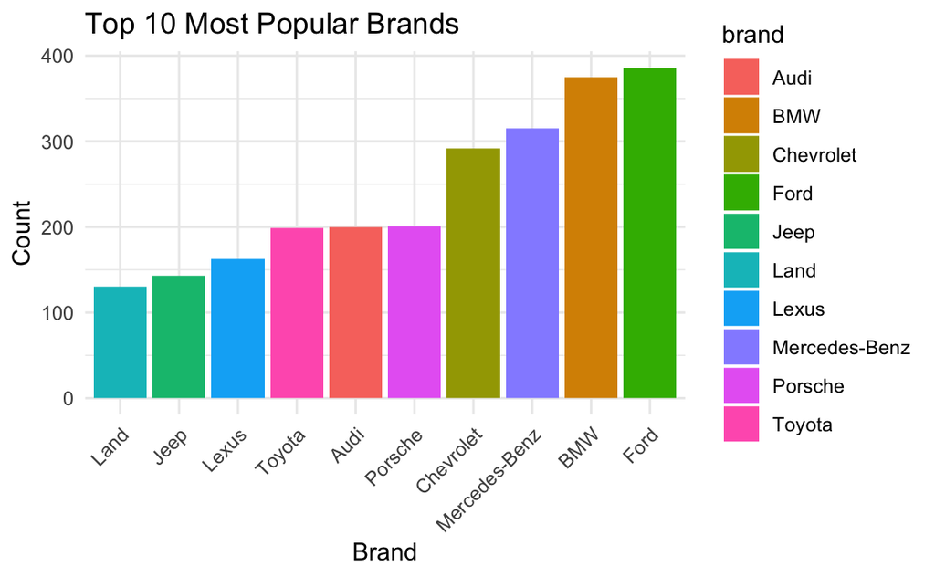

```r
# Bar chart of the 10 most popular brands
top_brands <- used_cars_dataset %>%
  group_by(brand) %>%
  summarize(count = n()) %>%
  arrange(desc(count)) %>%
  slice_head(n = 10)

ggplot(top_brands, aes(x = reorder(brand, count), y = count, fill = brand)) +
  geom_bar(stat = "identity") +
  labs(title = "Top 10 Most Popular Brands",
       x = "Brand",
       y = "Count") +
  theme_minimal() +
  theme(axis.text.x = element_text(angle = 45, hjust = 1))
```

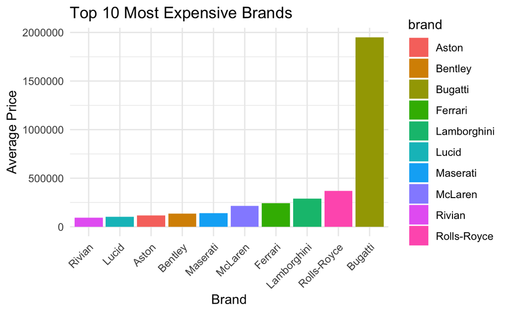

```r
# Calculate the average price for each brand and select the top 10 most expensive
top_expensive_brands <- used_cars_dataset %>%
  group_by(brand) %>%
  summarize(avg_price = mean(price, na.rm = TRUE)) %>%
  arrange(desc(avg_price)) %>%
  slice_head(n = 10)

# Bar chart of the 10 most expensive brands
ggplot(top_expensive_brands, aes(x = reorder(brand, avg_price), y = avg_price, fill = brand)) +
  geom_bar(stat = "identity") +
  labs(title = "Top 10 Most Expensive Brands",
       x = "Brand",
       y = "Average Price") +
  theme_minimal() +
  theme(axis.text.x = element_text(angle = 45, hjust = 1))
```

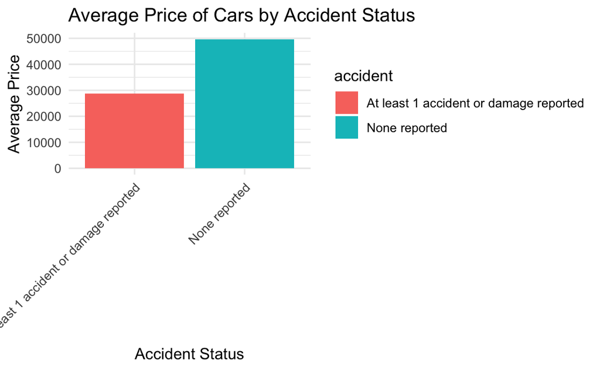

```r
# Average price based on accident status
average_price_accident <- used_cars_dataset %>%
  group_by(accident) %>%
  summarize(avg_price = mean(price, na.rm = TRUE)) %>%
  filter(accident %in% c("At least 1 accident or damage reported", "None reported"))

ggplot(average_price_accident, aes(x = accident, y = avg_price, fill = accident)) +
  geom_bar(stat = "identity") +
  labs(title = "Average Price of Cars by Accident Status",
       x = "Accident Status",
       y = "Average Price") +
  theme_minimal() +
  theme(axis.text.x = element_text(angle = 45, hjust = 1))
```

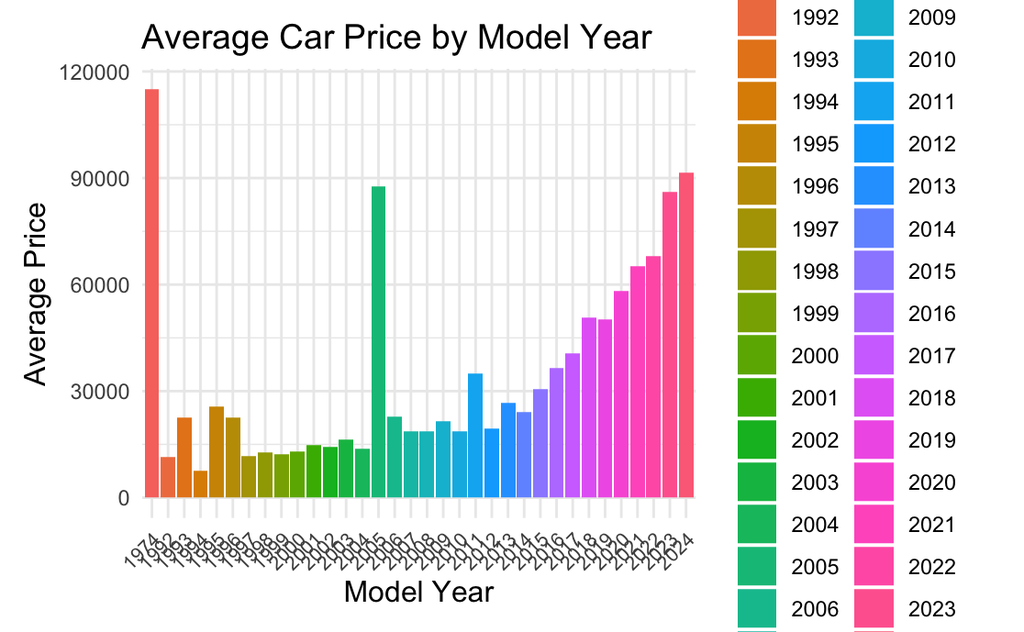

```r
# Average Car Price by Model Year
average_price_by_year <- used_cars_dataset %>%
  group_by(model_year) %>%
  summarize(avg_price = mean(price, na.rm = TRUE)) %>%
  arrange(model_year)

ggplot(average_price_by_year, aes(x = factor(model_year), y = avg_price, fill = factor(model_year))) +
  geom_bar(stat = "identity") +
  labs(title = "Average Car Price by Model Year",
       x = "Model Year",
       y = "Average Price") +
  theme_minimal() +
  theme(axis.text.x = element_text(angle = 45, hjust = 1, size = 8),  # Rotate and shrink x-axis labels
        axis.title = element_text(size = 12),
        plot.title = element_text(size = 14),
        plot.margin = margin(10, 20, 10, 10))
```

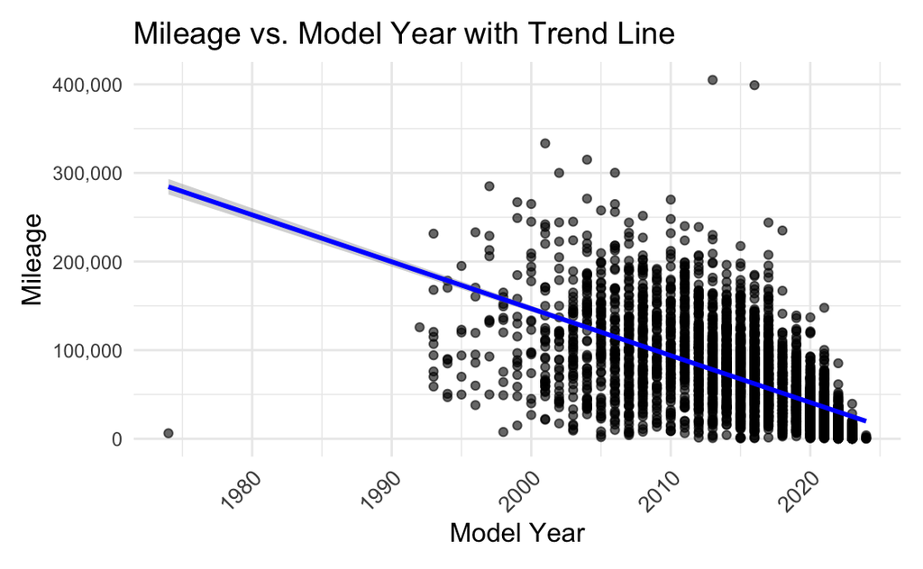

```r
# Mileage vs. Model Year with Trend Line
ggplot(used_cars_dataset, aes(x = model_year, y = mileage)) +
  geom_point(alpha = 0.6) +
  geom_smooth(method = "lm", color = "blue") +
  labs(title = "Mileage vs. Model Year with Trend Line",
       x = "Model Year",
       y = "Mileage") +
  theme_minimal() +
  theme(axis.text.x = element_text(angle = 45, hjust = 1, size = 10),
        axis.title = element_text(size = 12),
        plot.title = element_text(size = 14),
        plot.margin = margin(10, 10, 10, 10)) +
  scale_y_continuous(labels = scales::comma)
```

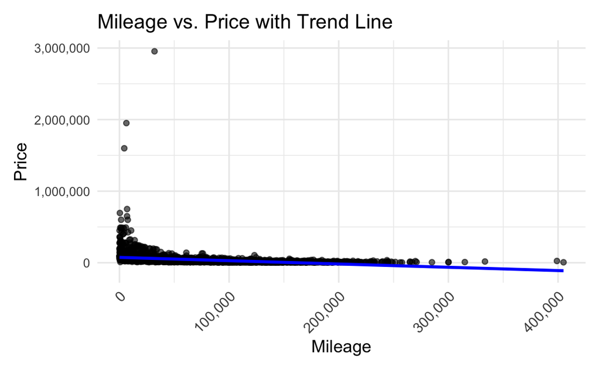

```r
# Mileage vs. Price with Trend Line
ggplot(used_cars_dataset, aes(x = mileage, y = price)) +
  geom_point(alpha = 0.6) +
  geom_smooth(method = "lm", color = "blue") +
  labs(title = "Mileage vs. Price with Trend Line",
       x = "Mileage",
       y = "Price") +
  scale_x_continuous(labels = scales::comma) +
  scale_y_continuous(labels = scales::comma) +
  theme_minimal() +
  theme(axis.text.x = element_text(angle = 45, hjust = 1, size = 10),
        axis.title = element_text(size = 12),
        plot.title = element_text(size = 14),
        plot.margin = margin(10, 10, 10, 10))
```